# Untitled

Ruoyuan Qian

2019/11/12

# Problem 1

```r
brain = read_excel("data\\Brain.xlsx") %>%
   janitor::clean_names()
```

## a)

```r
brain_non =
  brain %>%
  filter(!(species == "Homo sapiens"))

fit = lm(glia_neuron_ratio ~ ln_brain_mass,brain_non)
summary(fit)
```

```
##
## Call:
## lm(formula = glia_neuron_ratio ~ ln_brain_mass, data = brain_non)
##
## Residuals:
##      Min       1Q   Median       3Q      Max
## -0.24150 -0.12030 -0.01787  0.15940  0.25563
##
## Coefficients:
##               Estimate Std. Error t value Pr(>|t|)
## (Intercept)    0.16370    0.15987   1.024 0.322093
## ln_brain_mass  0.18113    0.03604   5.026 0.000151 ***
## ---
## Signif. codes:  0 '***' 0.001 '**' 0.01 '*' 0.05 '.' 0.1 ' ' 1
##
## Residual standard error: 0.1699 on 15 degrees of freedom
## Multiple R-squared:  0.6274, Adjusted R-squared:  0.6025
## F-statistic: 25.26 on 1 and 15 DF,  p-value: 0.0001507
```

## b)

```r
coef = summary(fit)$coefficients[2,1]
err  = summary(fit)$coefficients[1,1]

ln_brain_mass_human =
  brain %>%
  filter(species == "Homo sapiens") %>%
  pull(ln_brain_mass)


glia_human = coef*ln_brain_mass_human + err
```

## c)

using PI

## d)

```r
brain_human =
  brain %>%
  filter(species == "Homo sapiens")

pred_fit <- predict.lm(fit, interval="prediction")
PI_all <- data.frame(cbind(brain$ln_brain_mass,
                           brain$glia_neuron_ratio,
                           pred_fit))
human_PI_lwr = PI_all[[1,4]]
human_PI_upr = PI_all[[1,5]]


human_PI_upr > brain_human$glia_neuron_ratio
```

```
## [1] FALSE
```

Yes, the upper bound of prediction for glia_neuron_ratio of human is smaller than the observed value, which means the human brain has excessive glia_neuron_ratio than other specise.

## e)

Compared to data of other species, human data is considered to be an outlier and would affect the regression if it was used to fit the model.

# Problem 4

```r
heart = read_csv("data\\HeartDisease.csv") %>%
   janitor::clean_names() %>%
  mutate(gender = factor(gender,level=c(0:1),
                         labels = c("female","male")))
```

## a)

**Description**:

The dataset is collected by an insurance company about the total cost of heart disease and other relevant events caused by heart disease. The main outcome is total cost from the heart disease (`totalcost`), and the main predictor is the number of emergency room (ER) visits (`e_rvisits`). There are other important variables like `age` and `gender` of subject, total number of interventions carried out(`interventions`), the number of tracked drugs (`drugs`), the number of other complications arose due to other disease instead of heart disease (`complications`), the number of other disease during the period (`comorbidities`), the number of days of treated duration (`duration`).

Descriptive statistics

```r
 sum_data  <-  arsenal::tableby( ~ totalcost + age + gender +
                                        interventions + drugs+
                                        e_rvisits+complications+
                                         comorbidities+duration,
                                data  = heart,
                                test  = FALSE,
                                total = FALSE,
                                numeric.stats = c("meansd" ,"medianq1q3","range" ) )
 summary(sum_data,text = TRUE)
```

```
##
##
## |                   |       Overall (N=788)       |
## |:------------------|:---------------------------:|
## |totalcost          |                             |
## |-  Mean (SD)       |     2799.956 (6690.260)     |
## |-  Median (Q1, Q3) | 507.200 (161.125, 1905.450) |
## |-  Range           |      0.000 - 52664.900      |
## |age                |                             |
## |-  Mean (SD)       |       58.718 (6.754)        |
## |-  Median (Q1, Q3) |   60.000 (55.000, 64.000)   |
## |-  Range           |       24.000 - 70.000       |
## |gender             |                             |
## |-  female          |         608 (77.2%)         |
## |-  male            |         180 (22.8%)         |
## |interventions      |                             |
## |-  Mean (SD)       |        4.707 (5.595)        |
## |-  Median (Q1, Q3) |    3.000 (1.000, 6.000)     |
## |-  Range           |       0.000 - 47.000        |
## |drugs              |                             |
## |-  Mean (SD)       |        0.447 (1.064)        |
## |-  Median (Q1, Q3) |    0.000 (0.000, 0.000)     |
## |-  Range           |        0.000 - 9.000        |
## |e_rvisits          |                             |
## |-  Mean (SD)       |        3.425 (2.637)        |
## |-  Median (Q1, Q3) |    3.000 (2.000, 5.000)     |
## |-  Range           |       0.000 - 20.000        |
## |complications      |                             |
## |-  Mean (SD)       |        0.057 (0.248)        |
## |-  Median (Q1, Q3) |    0.000 (0.000, 0.000)     |
## |-  Range           |        0.000 - 3.000        |
## |comorbidities      |                             |
## |-  Mean (SD)       |        3.766 (5.951)        |
## |-  Median (Q1, Q3) |    1.000 (0.000, 5.000)     |
## |-  Range           |       0.000 - 60.000        |
## |duration           |                             |
## |-  Mean (SD)       |      164.030 (120.916)      |
## |-  Median (Q1, Q3) |  165.500 (41.750, 281.000)  |
## |-  Range           |       0.000 - 372.000       |
```

## b)

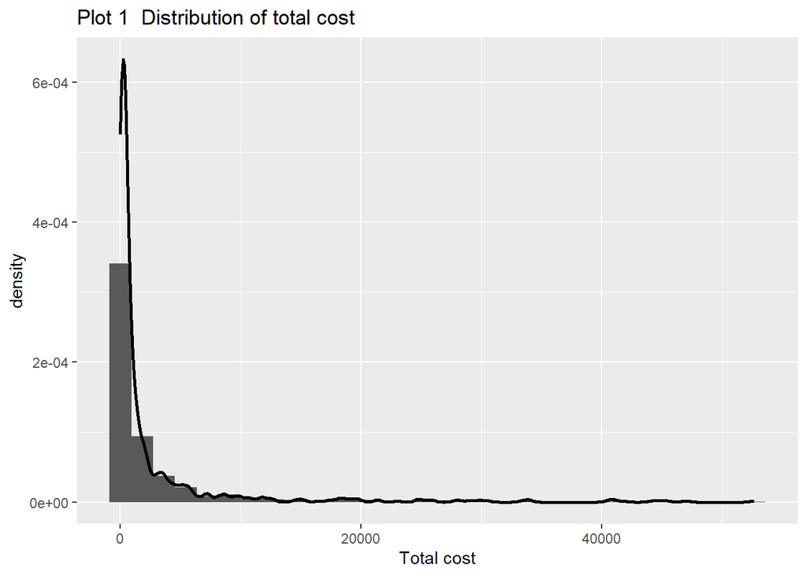

```r
heart %>%
  ggplot(aes(totalcost,..density..))+
 geom_histogram()+
 geom_line(stat = 'Density',size = 1)+
    labs(x = "Total cost",
         title = "Plot 1  Distribution of total cost")
```

Different transformation

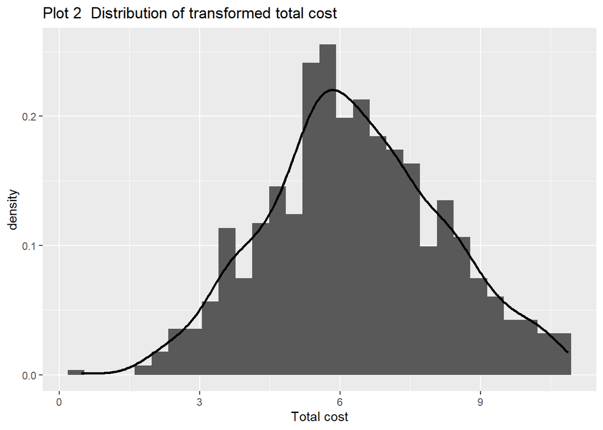

```r
heart_log =
 heart %>%
  mutate(log_totalcost = log(totalcost))

heart_log %>%
  ggplot(aes(log_totalcost,..density..))+
 geom_histogram()+
 geom_line(stat = 'Density',size = 1)+
    labs(x = "Total cost",
         title = "Plot 2  Distribution of transformed total cost")
```

## c)

```r
heart_log_bin =
heart_log %>%
  mutate(comp_bin =
           case_when(
      complications == 0 ~ 0,
      complications > 0 ~ 1))
```

## d)

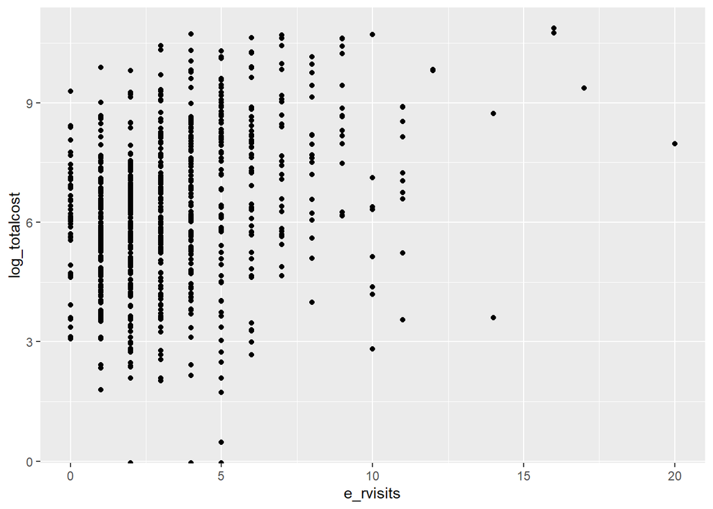

```r
heart_log_bin %>%
  mutate(log_totalcost = log(totalcost)) %>%
ggplot(aes(y = log_totalcost, x = e_rvisits))+
  geom_point()
```

```r
heart_fill =
heart_log_bin %>%
  filter(log_totalcost >= 0 )

fit = lm(log_totalcost ~ e_rvisits,heart_fill)
summary(fit)
```

```
##
## Call:
## lm(formula = log_totalcost ~ e_rvisits, data = heart_fill)
##
## Residuals:
##     Min      1Q  Median      3Q     Max
## -6.2013 -1.1265  0.0191  1.2668  4.2797
##
## Coefficients:
##             Estimate Std. Error t value Pr(>|t|)
## (Intercept)  5.53771    0.10362   53.44   <2e-16 ***
## e_rvisits    0.22672    0.02397    9.46   <2e-16 ***
## ---
## Signif. codes:  0 '***' 0.001 '**' 0.01 '*' 0.05 '.' 0.1 ' ' 1
##
## Residual standard error: 1.772 on 783 degrees of freedom
## Multiple R-squared:  0.1026, Adjusted R-squared:  0.1014
## F-statistic:  89.5 on 1 and 783 DF,  p-value: < 2.2e-16
```

## e)

### i)

```r
reg2 = lm(log_totalcost ~ e_rvisits + factor(comp_bin),heart_fill)
summary(reg2)
```

```
##
## Call:
## lm(formula = log_totalcost ~ e_rvisits + factor(comp_bin), data = heart_fill)
##
## Residuals:
##     Min      1Q  Median      3Q     Max
## -6.0741 -1.0737 -0.0181  1.1810  4.3848
##
## Coefficients:
##                   Estimate Std. Error t value Pr(>|t|)
## (Intercept)         5.5211     0.1013  54.495  < 2e-16 ***
## e_rvisits           0.2046     0.0237   8.633  < 2e-16 ***
## factor(comp_bin)1   1.6859     0.2749   6.132 1.38e-09 ***
## ---
## Signif. codes:  0 '***' 0.001 '**' 0.01 '*' 0.05 '.' 0.1 ' ' 1
##
## Residual standard error: 1.732 on 782 degrees of freedom
## Multiple R-squared:  0.1437, Adjusted R-squared:  0.1416
## F-statistic: 65.64 on 2 and 782 DF,  p-value: < 2.2e-16
```

```r
coef_after = summary(reg2)$coefficients[2,1]
```

### ii)

```r
reg1 = lm(log_totalcost ~ e_rvisits ,heart_fill)
summary(reg1)
```

```
##
## Call:
## lm(formula = log_totalcost ~ e_rvisits, data = heart_fill)
##
## Residuals:
##     Min      1Q  Median      3Q     Max
## -6.2013 -1.1265  0.0191  1.2668  4.2797
##
## Coefficients:
##             Estimate Std. Error t value Pr(>|t|)
## (Intercept)  5.53771    0.10362   53.44   <2e-16 ***
## e_rvisits    0.22672    0.02397    9.46   <2e-16 ***
## ---
## Signif. codes:  0 '***' 0.001 '**' 0.01 '*' 0.05 '.' 0.1 ' ' 1
##
## Residual standard error: 1.772 on 783 degrees of freedom
## Multiple R-squared:  0.1026, Adjusted R-squared:  0.1014
## F-statistic:  89.5 on 1 and 783 DF,  p-value: < 2.2e-16
```

```r
coef_before = summary(reg1)$coefficients[2,1]
```

```r
rate = (coef_after - coef_before)/coef_before
 rate > 0.1
```

```
## [1] FALSE
```

Since the changing rate of coefficient of `ERvisits` is smaller than 10% after putting the `comp_bin` into model, the `comp_bin` is not a confounder between `total cost` and `ERvisits`.

### iii)

```r
anova(reg1,reg2)
```

```
## Analysis of Variance Table
##
## Model 1: log_totalcost ~ e_rvisits
## Model 2: log_totalcost ~ e_rvisits + factor(comp_bin)
##   Res.Df    RSS Df Sum of Sq      F    Pr(>F)
## 1    783 2459.8
## 2    782 2347.0  1    112.84 37.598 1.379e-09 ***
## ---
## Signif. codes:  0 '***' 0.001 '**' 0.01 '*' 0.05 '.' 0.1 ' ' 1
```

## f)

```r
reg_m = lm(log_totalcost ~ e_rvisits + age + gender + duration, heart_fill)
summary(reg_m)
```

```
##
## Call:
## lm(formula = log_totalcost ~ e_rvisits + age + gender + duration,
##     data = heart_fill)
##
## Residuals:
##     Min      1Q  Median      3Q     Max
## -5.3012 -1.0790 -0.1215  1.0567  4.2854
##
## Coefficients:
##               Estimate Std. Error t value Pr(>|t|)
## (Intercept)  6.1967450  0.5162986  12.002  < 2e-16 ***
## e_rvisits    0.1946147  0.0225477   8.631  < 2e-16 ***
## age         -0.0249155  0.0087695  -2.841  0.00461 **
## gendermale  -0.1189335  0.1408787  -0.844  0.39880
## duration     0.0057155  0.0004941  11.569  < 2e-16 ***
## ---
## Signif. codes:  0 '***' 0.001 '**' 0.01 '*' 0.05 '.' 0.1 ' ' 1
##
## Residual standard error: 1.639 on 780 degrees of freedom
## Multiple R-squared:  0.2359, Adjusted R-squared:  0.232
## F-statistic:  60.2 on 4 and 780 DF,  p-value: < 2.2e-16
```

### ii)

I will use the MLR to address the interest problem of investigator. In the MLR, the coefficient of main predictor (`ERvisits`) is more precise due to the adjustment of other covariates, which may bias the reslut.